# STAT1379 & COMP6179 Statistical Technologies for Data Science

Assignment/Problem Set 2

## Submission details

- **Total marks**: 100, scaled to 30% of the unit marks
- **Due date/Time**: Friday of Week 10, 16 October 2026, 11:55 PM
- Late submission is allowed. Standard Late Penalty applies.
- **Submission** via iLearn and a separate submission via Classroom 50.

## Folder structure Overview

Your submission should be organised around a valid R package structure first, then place your report and supporting files into the appropriate package locations so they do not interfere with package build/check.

## Core principle

Build a standard R package (for Exercise 5), and treat your report materials (`qmd`, bibliography, any vignette assets) as `vignette/article` content inside the package, not as loose files scattered around the project. This keeps the package installable and ensures `check()` behaves as expected.

## What goes where

### 1. Package root (top level)

Your R package must live at the top level of your project (the folder you open in RStudio). This top-level folder should be a standard, installable R package, with all files placed in appropriate package locations.

Include a working `.Rproj` file at the package root so the marker can open the project and immediately be in the correct working directory. The intent is that the `.Rproj` sets the base directory and your code can use `here::here()` to reliably find files.

In your final submission zip, include the entire package folder (not just selected files), so the package can be installed and checked as-is.

### 2. Vignette/article files

If you are attempting Exercise 5, place your single `qmd` source file inside: `vignettes/article/`.

Create this structure correctly using: `usethis::use_article()` in Console.

This is important because it generates the correct structure; manually creating folders with the same name may not behave the same way.

Also place in the same folder:

- your `.bib` references file (for the report)
- any report assets you need (for example images), if relevant

### 3. Data files

Put data in one of these locations, depending on its role:

- Package dataset(s) you want to include as part of the package: follow standard package conventions (for Exercise 5 you are explicitly adding the provided dataset and documenting it).
- Raw/source data for processing: `data-raw/` is acceptable.
- Data needed only for the report/vignette rendering: may be placed in `vignettes/article/`.

## Notes about `check()`

When you run `check()` for your package, you may see a message about deleting an empty vignettes folder even if you have files under `vignettes/article/`. That message is expected, and you do not need to fix anything.

## What to include in the final zip

Submit a single zip named `firstname_lastname_SID_Assignment2.zip` containing:

- your Exercise 5 package, including the `.Rproj`
- `vignettes/article/` containing:
  - one `.qmd` file
  - one `.bib` file
  - any supporting files you used for the report (as needed)
- any data files placed under `data-raw/` and/or `vignettes/article/` as appropriate

This structure keeps the package compliant and reduces the chance that report files disrupt installation or package checks.

# Exercise 1 [10 marks]

As the output of this exercise, you are required to submit your code and its output under a section in your `qmd` file.

The Programme for International Student Assessment (PISA) is an international assessment measuring student performance in reading, mathematical and scientific literacy.

PISA assesses the extent to which 15-year-old students have acquired some of the knowledge and skills that are essential for full participation in society, and how well they are prepared for lifelong learning in the areas of reading, mathematical and scientific literacy.

In 2022, PISA involved 80 countries and 610,000+ students worldwide. The records for a subset of countries are saved in the `pisa_2022.csv` file and contain the following variables:

| variable | class | description |
| --- | --- | --- |
| country | character | 3-letter country code. |
| gender | character | Gender of the student. Only ‘male’ and ‘female’ are recorded. |
| math | double | Simulated score in mathematics. |
| read | double | Simulated score in reading. |
| science | double | Simulated score in science. |

For this question, you have to reproduce the following two visualisations. You may also have to perform some data wrangling. Each plot is worth 5 marks.

#### Plot 1

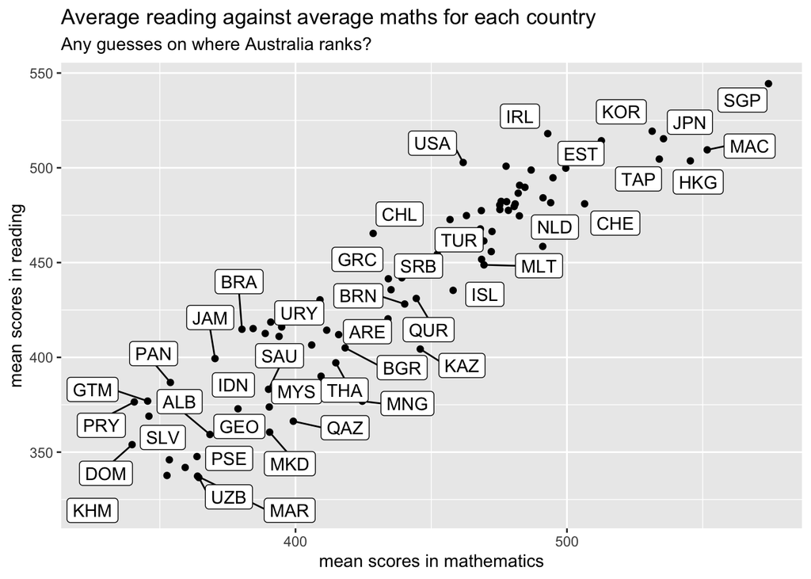

#### Plot 2

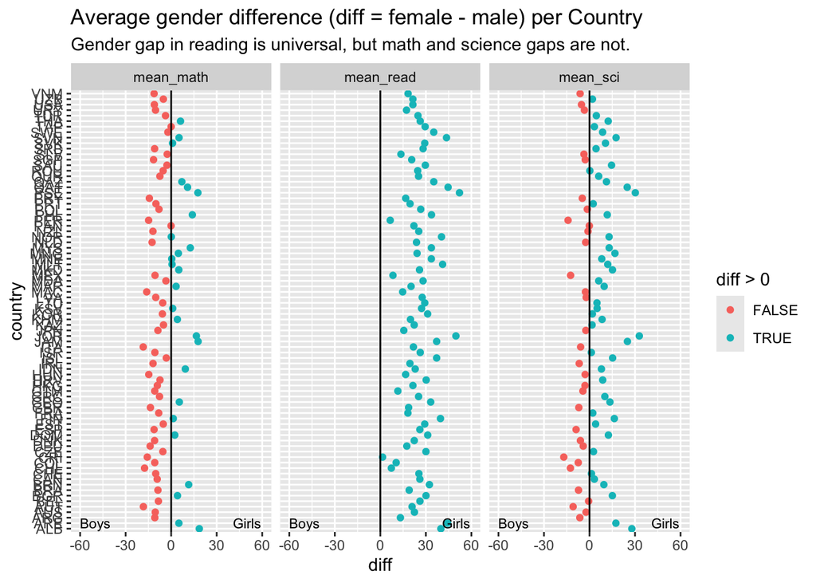

**TipHint**

- I used `ggrepel::geom_label_repel` to generate the label in the scatterplot with the default `max.overlaps` setting. Depending on the size of your plot/window, you may display more or less of the labels.
- Both plots here are created with chunk options of `fig.width=7`, `fig.height=5`.

# Exercise 2 [10 marks]

As the output of this exercise, you are required to submit your code and its output under a section in your `qmd` file.

The inspiration for this exercise comes from https://fred.stlouisfed.org/series/MSPUS. The two datasets you’ll use are `aus_median_house_price.csv` and `aus_GDP_changes.csv`, both of which are available on iLearn.

Please note that `aus_median_house_price.csv` is considered as a *wild-caught* dataset as it was downloaded directly from this ABS website without any further cleaning/wrangling by us: https://www.abs.gov.au/statistics/economy/price-indexes-and-inflation/total-value-dwellings/latest-release.

Please also note that the GDP changes data in `aus_GDP_changes.csv` is recorded as percentages.

For this question, you need to:

1. Load the two datasets using `read_csv()`.
2. [1 mark] Tidy/clean up `aus_median_house_price.csv` in `R`. We are only interested in the `Melbourne` Median Price of Established House Transfers (Unstratified) data in the file.
3. [4 marks] Create the following visualisation.

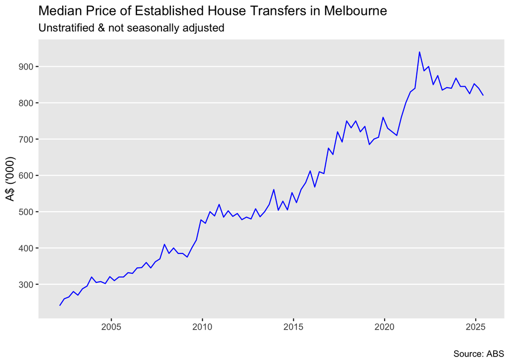

4. [1 mark] Identify periods of very low to negative GDP growth (defined as GDP change of less than 0.1 (%)) that occurred during the time frame of the `aus_median_house_price` dataset. Do this by adding a new variable that takes the value `TRUE` if a low GDP growth period occurred during this time frame and `FALSE` if not. Only keep the records after 1 March 2002, which is the first date for which Melbourne median house price series is available in `aus_median_house_price`.
5. [4 marks] Now recreate the following visualisation. The shaded areas should represent periods with very low GDP growth that occurred during the time frame of the `aus_median_house_price` dataset.

**TipHint**

There are many ways to create these shaded areas, and you will get full marks as long as you can match the general look and layout of the plot. `geom_rect()` was used in the plot.

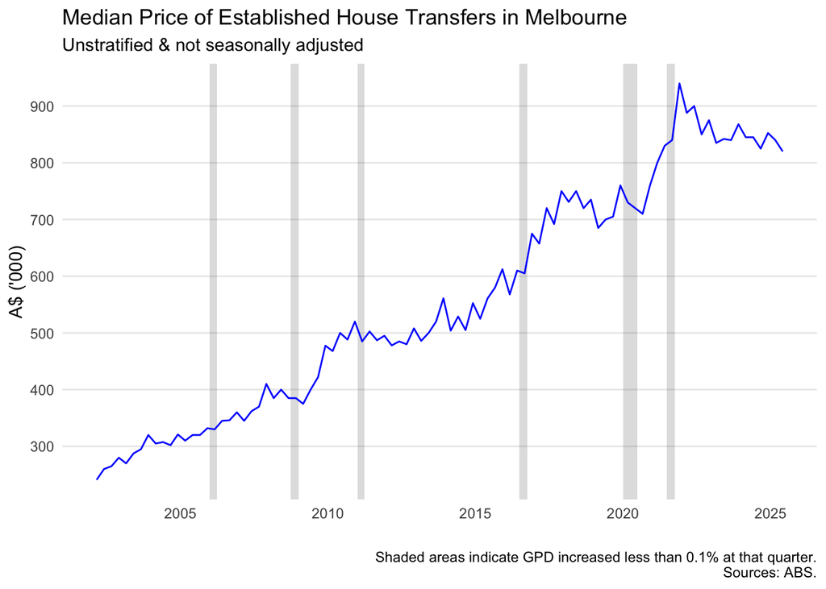

**TipHint**

- Both plots here are once again created with chunk options of `fig.width=7`, `fig.height=5`.

# Exercise 3 [10 marks]

As the output of this exercise, you are required to submit your code and its output under a new section in your `qmd` file.

Recall the `Movie` database we created in Week 7 SGTA. The code and relevant csv files for this exercise can be found there.

1. [5 marks] Write `dbplyr` code and show its output to identify the most common director–actor partnerships in the database.
2. [5 marks] Consider the following `SQL` query:

```
SELECT
  "Name.x",
  COUNT(DISTINCT "Name.y") AS unique_directors,
  COUNT(*) AS total_movies
FROM (
  SELECT
    actors.ActorID AS ActorID,
    actors."Name" AS "Name.x",
    CastingID,
    castings.MovieID AS MovieID,
    "Character",
    Title,
    "Year",
    movies.DirectorID AS DirectorID,
    directors."Name" AS "Name.y"
  FROM actors
  LEFT JOIN castings
    ON (actors.ActorID = castings.ActorID)
  LEFT JOIN movies
    ON (castings.MovieID = movies.MovieID)
  LEFT JOIN directors
    ON (movies.DirectorID = directors.DirectorID)
) q01
GROUP BY "Name.x"
ORDER BY unique_directors DESC
```

Translate this query into `dbplyr` syntax and execute it to obtain the output. Briefly discuss what insights can be drawn from the results. Alternatively, you may frame your response by considering what kind of question could have motivated such a query.

# Exercise 4 [40 marks]

As the output of this exercise, you are required to submit your report under a new section or multiple sections in your `qmd` file.

In this question, we are going to compare two methods used in the analysis of 2-by-2 contingency tables. One is the `chi-squared test`, and the other is the `Fisher's exact test`.

We will use this example based on the one from the `Fisher's exact test` Wiki page. A sample of teenagers might be divided into male and female on the one hand and those that are and are not currently studying for a statistics exam on the other. For simplicity, we will be conducting a two-sided test, i.e. testing whether the proportion of studying individuals is the same for both genders or not. The observed frequencies are

|  | Men | Women |
| --- | --- | --- |
| Studying | 3 | 27 |
| Not-studying | 33 | 9 |

As output, you need to include your report/write up as part of your `qmd` file with the appropriate sections/dividers.

You can solve this exercise at different levels. Please state in your report which level you are aiming for.

- Pass [0-20 marks]: Produce an `qmd` file that will generate a reproducible **html** report describing/summarising the `chi-squared test` and its application. You can use the example above as an illustration. You are welcome to base this on the notes you had from your 1000 level Statistics units and the Wikipedia page about the $\chi^2$ test, but please do not copy the content from the Wikipedia page directly. Make sure you use the function that matches the method described in your report. You should also include multiple citations, including at least one journal article, one book and one package (if you used a package, you can cite it even they are not $\chi^2$ test related).  
  To achieve full marks for a Pass level attempt, we expect
  - your report to be a part of an `qmd` file that formatted correctly with no compiling errors
  - all R code will be run in the background and not be visible on your final report;
  - correct usage of the section/ordered list/unordered list environment;
  - all mathematical expressions & tables will be typeset appropriately in your `qmd` file;
  - at least 3 correctly formatted citations, including one book, one journal & one package;
  - an appropriate summary of the statistical concepts underpinning a $\chi^2$ test.
- Credit [21-26 marks]: As at the pass level, but more tasks are handled by `R`
  - All calculations/results will be handled/populated by `R`;
  - All citations & in-line references are generated from a BibTex file.
- Distinction [27-32 marks]: As at the credit level, but added another (sub-)section based on the `Fisher's exact test`.
  - Once again, you have to describe/summarise the method and use the provided dataset to illustrate. You can base this on its Wikipedia page https://en.wikipedia.org/wiki/Fisher%27s_exact_test but please do not copy the content from the Wikipedia page directly.
- High Distinction [33-40 marks]: As at the distinction level, but added another (sub-)section and investigate this statement from the Fisher’s exact test’s Wikipedia page: “*Despite the fact that Fisher’s test gives exact p-values, some authors have argued that it is conservative, i.e. that its actual rejection rate is below the nominal significance level.*”

  Your task is to investigate the above statement by conducting a simulation study. You have to generate 10,000 2-by-2 contingency tables in 4 different settings (so 40,000 in total). Using the terminology as the example we had above, and the 4 different settings are:
  - Setting 1 (Small sample size, small $p$): There will be a fixed 20 Men and 20 Women at each iteration and then a 20% success rate of those to be randomly allocated to the `Studying` group.
  - Setting 2 (Small sample size, normal $p$): There will be a fixed 20 Men and 20 Women at each iteration and then a 50% success rate of those to be randomly allocated to the `Studying` group.
  - Setting 3 (Large sample size, small $p$): There will be a fixed 100 Men and 100 Women at each iteration and then a 20% success rate of those to be randomly allocated to the `Studying` group.
  - Setting 4 (Large sample size, normal $p$): There will be a fixed 100 Men and 100 Women at each iteration and then a 50% success rate of those to be randomly allocated to the `Studying` group.

  For each contingency table, run both the $\chi^2$ test and Fisher’s exact test and collect their $P$-values. You can then compare the rejection proportion based on three significance levels: 10%, 5% and 1%. Summarise your findings.

**WarningSome important notes/requirements for Question 4**

- In Setting 1, you may end up with no student in the “Studying” group by chance. Your code will have to check and replace such a sample if it happens.
- In Settings 1 & 2, you can ignore any warning messages when the assumption for the $\chi^2$ test is not satisfied.

# Exercise 5 [20 marks]

Your task for this exercise is to create an R package using the script `Multiserver.R` (available on iLearn), which is used to simulate how customers will go through a first come, first serve queuing system as long as “fate” has already decided when each customer will arrive and their service times.

For those who are interested in the logic behind `Multiserver.R`, we can use `bankmodel.xlsx` (available on iLearn) to illustrate a queuing system in a bank. Notice that those times can be regenerated, so the numbers on the spreadsheet may differ from those shown below.

We want to calculate the times at which each customer’s service time starts and ends. Consider Customer 6. The highlighted times show when the three servers will become available after dealing with Customers 1 through 5.

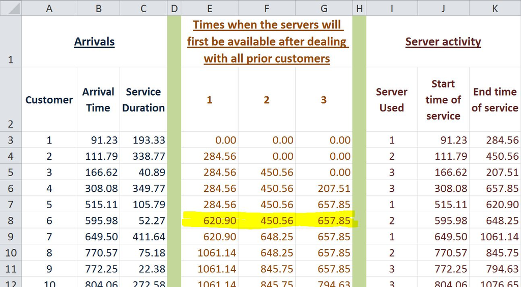

Server 2 becomes available at time 450.56, earlier than the other two servers, so we determine that Customer 6 will go to Server 2 (and that is shown in cell `I8`).

However, Customer 6’s service does not start at time 450.56–because, at that time, Customer 6 hasn’t arrived yet! Cell `J8` is later of cells `B8` and `F8`, i.e., the transaction begins when the customer and server are *both* ready.

Adding the transaction duration (from cell `C8`) gives the time shown in `K8`, when the transaction finishes and Customer 6 leaves the bank. Lastly, that time, 648.25, becomes the new next-available time for Server 2 and is copied down to cell `F9`.

The tabular simulation fully describes the comings and goings of customers through the system. We could then use this simulation to answer various questions about the system. For instance, how would we calculate the average time that each customer had to wait in the queue? Also, adding another server to the system would reduce the average waiting time, but by how much? Feel free to explore the answers to these questions, but they are not part of this assignment.

All we need at this stage is some arrival and service times. To get you started, you can find `bank.csv` on iLearn, which was generated by using the following code.

```r
# to generate 100 customer's arrival time and their service times
set.seed(2048)
# customers arrived according to a Poisson Process
# = inter arrival time has an exponential distribution
# Set arrival rate to one per 60 seconds = mean inter-arrival time is 60s
arrival_time <- cumsum(rexp(100, 1 / 60))
# service time is exponential distributed with mean 150s + 20s greeting
service_time <- rexp(length(arrival_time), 1 / 150) + 20
bank <- data.frame(arrival_time, service_time)
```

For this question, you have to

- Create an R package with all the appropriate documentation.
- Add the bank dataset to your package.
- Implement `testthat` with **at least 2 expectations or snapshots**.
- Currently we used `data.frame()` on line 34 in `Multiserver()`. Change that to `tibble()` and update the package accordingly.

A marking rubric/checklist for this question can be found below. Please add a section on your `qmd` file to indicate which tasks were completed/attempted.

**TipTips**

- Notice that you don’t have to create a “Page” for your repo and you also don’t have to implement continuous integration with GitHub action for this exercise. You can’t activate “Pages” because your repo is private and GitHub provides very limited server time to allow continuous integration for everyone.
- You shouldn’t use `usethis::use_github()` to upload your repo to GitHub in this question as we want you to push it to a existing repo from our Classroom 50. To successfully submit your work to the one under Classroom 50, you can either
  - clone the blank Classroom 50 repo into your computer and then start working/move your files there.
  - push an existing repository by *adopting* the following code for the command line/Terminal:

  ```markdown
  git remote add origin https://github.com/<OWNER>/<REPO>.git
  git branch -M main
  git push -u origin main
  ```

#### Marking Check List for Exercise 5

- Had the correct R package structure; files were put in appropriate locations; the package can be installed [5 marks]
- Had all the appropriate documentation for the package [5 marks]
- Added the provided dataset with proper documentation to the package [4 marks]
- Implemented `testthat` correctly [4 marks]
- Implemented `tibble` [2 marks]

# Exercise 6 [10 marks]

In addition to submitting a single ZIP file via iLearn, you are required to submit your work through Classroom 50 to be eligible for assessment of the repository component of this exercise. The Classroom 50 invitation link is available on iLearn and must be used to create your assignment repository. This ensures the teaching team can access your **private** repository for marking purposes.

- Only repositories created by accepting the official Classroom 50 invitation link for this assessment will be eligible for marking.
- Repositories created outside the Classroom 50 workflow will not be considered.
- If you encounter any issues accessing, accepting, or using the Classroom 50 invitation link, you must contact the teaching team as soon as possible and prior to the submission deadline so that support can be provided.

To help the teaching team link your GitHub repository with your iLearn submission, please add your personal details to the `README.md` file in your project.

You will find the `README.md` file in your repository after accepting the assignment invitation. If not, run `usethis::use_readme_md()` in your console to add a `README.md` to your project/package.

This file is a simple text file that appears on the main page of your GitHub repository and is commonly used to describe a project or provide key information.

Open `README.md` in RStudio and add your details as an unordered list using the template below:

- Full Name:
- GitHub Username:
- Student ID (SID):
- MQ Email Address:

Save the file, then commit and push the change to GitHub.

Once the changes are pushed, you should be able to see your details displayed on the main page of your repository on GitHub.

Classroom 50 Workflow Rubric

[output not shown]